# Notebook: Explore Datasets

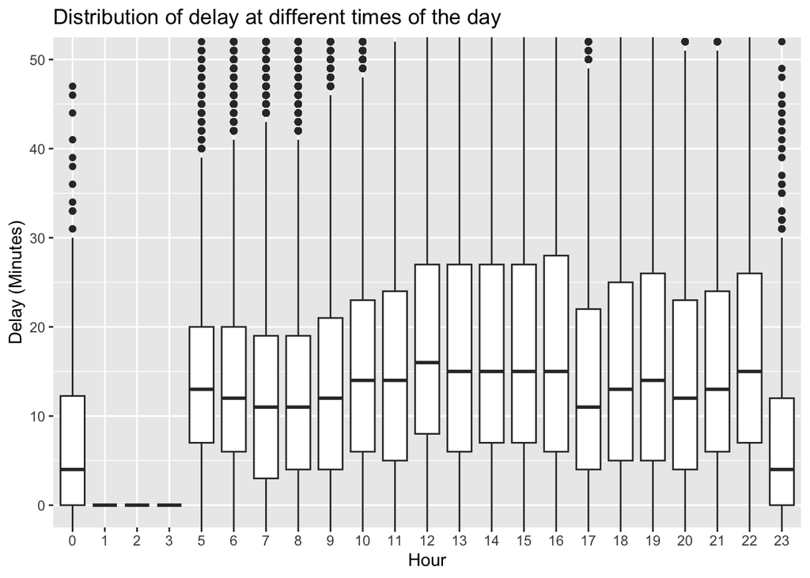

```r
ggplot(delay_departure_data, aes(x = as.factor(departure_scheduled_hour_local), y = delay_departure_min)) +
  geom_boxplot() +
  labs(x = "Hour", y = "Delay (Minutes)", title = "Distribution of delay at different times of the day") +
  coord_cartesian(ylim = c(0, 50))
```

There also seem to be differences depending on the day of the week, with the average delay being lowest on Tuesdays and highest on Fridays.

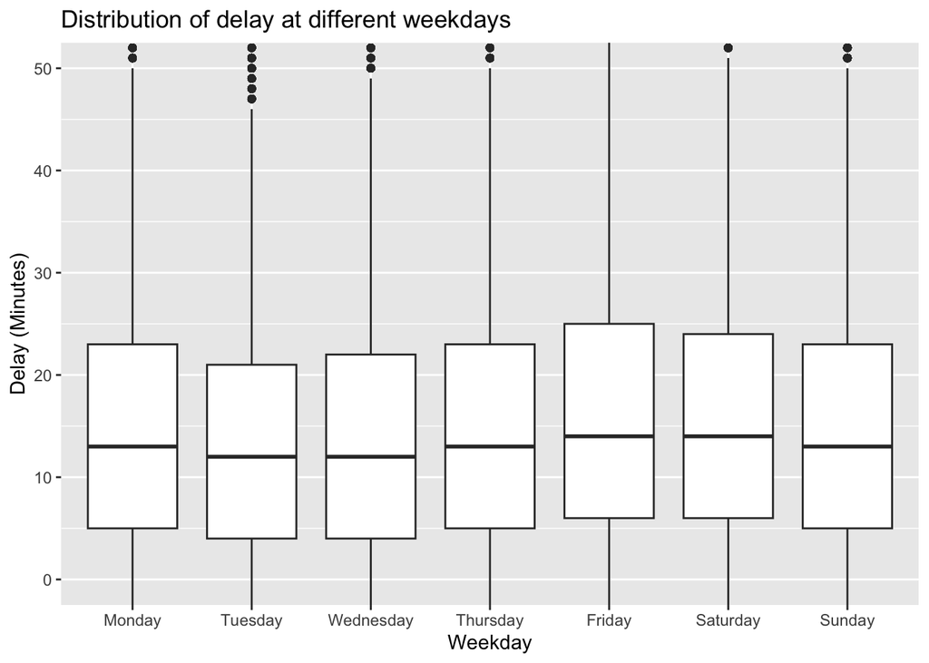

```r
delay_departure_data$departure_scheduled_weekday_local <- factor(delay_departure_data$departure_scheduled_weekday_local,
                                                               levels = c("Monday", "Tuesday", "Wednesday", "Thursday", "Friday", "Saturday", "Sunday"))

ggplot(delay_departure_data, aes(x = departure_scheduled_weekday_local, y = delay_departure_min)) +
  geom_boxplot() +
  labs(x = "Weekday", y = "Delay (Minutes)", title = "Distribution of delay at different weekdays") +
  coord_cartesian(ylim = c(0, 50))
```

There also seem to be differences between the airlines as to how long the delay is. For this we can look at the airlines that have at least one flight a day on average.

```r
top_airlines_delay <- delay_departure_data %>%
  group_by(airline_name, airline_country) %>%
  summarise(delay_mean = mean(delay_departure_min), delay_median = median(delay_departure_min), count = n()) %>%
  filter(count >= 365) %>%
  arrange(-delay_mean)
head(top_airlines_delay, n=20)
```

```
## # A tibble: 20 × 5
## # Groups:   airline_name [20]
##    airline_name              airline_country      delay_mean delay_median count
##    <chr>                     <chr>                     <dbl>        <dbl> <int>
##  1 bmi Regional              United Kingdom             30.1           20  1065
##  2 Air Malta                 Malta                      26.9           20   466
##  3 Adria Airways             Slovenia                   25.9           19   564
##  4 TAP - Air Portugal        Portugal                   24.4           19  1920
##  5 Turkish Airlines          Turkey                     24.1           19  1800
##  6 SunExpress                Turkey                     23.8           17  2285
##  7 Pegasus                   Turkey                     23.2           19   559
##  8 S7 - Siberia Airlines     Russia                     22.8           17   394
##  9 SAS Scandinavian Airlines <NA>                       21.7           16   887
## 10 Icelandair                Iceland                    21.4           18   443
## 11 British Airways           United Kingdom             20.2           15  2157
## 12 Aer Lingus                Ireland                    20.1           16   501
## 13 easyJet                   United Kingdom             19.9           12  2596
## 14 Condor                    Germany                    19.6           15  4663
## 15 Air Dolomiti              Italy                      19.4           14  5457
## 16 Vueling                   Spain                      18.2           11  1056
## 17 Air France                France                     18.1           14  2178
## 18 Emirates                  United Arab Emirates       17.8           15   872
## 19 Iberia                    Spain                      17.5           14  1340
## 20 Eurowings                 Germany                    17.5           12  9317
```

```r
top_flights_delay <- delay_departure_data %>%
  group_by(flight_number) %>%
  summarise(delay_mean = mean(delay_departure_min), delay_median = median(delay_departure_min), count = n()) %>%
  filter(count >= 365) %>%
  arrange(-delay_mean)

head(top_flights_delay, n = 20)
```

```
## # A tibble: 20 × 4
##    flight_number delay_mean delay_median count
##    <chr>              <dbl>        <dbl> <int>
##  1 XQ977               24.3           19   574
##  2 TP551               24.2           19   726
##  3 KL1796              24.1           18   437
##  4 TP553               23.8           19   783
##  5 XQ131               22.5           15   517
##  6 X34282              21.9           17   390
##  7 X32196              21.7           17   431
##  8 PC1020              21.7           18   367
##  9 LH109               21.5           16   452
## 10 FI533               21.0           18   414
## 11 SK2658              20.9           14   412
## 12 AF1823              19.9           13   480
## 13 LH1752              19.1           16   420
## 14 BA947               18.6           14   671
## 15 LH2372              18.5           12   377
## 16 LH2470              17.4           15   829
## 17 LH101               17.4           14   376
## 18 LH2300              17.4           14   780
## 19 LH2212              17.2           15   385
## 20 DE1600              16.9           14   472
```

Next, we can look at whether the destination has an influence. If we look again at destinations that are flown to at least once a day on average, we can see that there are differences.

```r
top_destination_delay <- delay_departure_data %>%
  group_by(destination_IATA, destination_name) %>%
  summarise(delay_mean = mean(delay_departure_min), delay_median = median(delay_departure_min), count = n()) %>%
  filter(count >= 365) %>%
  arrange(-delay_mean)
head(top_destination_delay, n=20)
```

```
## # A tibble: 20 × 5
## # Groups:   destination_IATA [20]
##    destination_IATA destination_name delay_mean delay_median count
##    <chr>            <chr>                 <dbl>        <dbl> <int>
##  1 PRN              Pristina               31.7         24     470
##  2 LGW              London                 29.3         22     511
##  3 EDI              Edinburgh              28.4         20     408
##  4 HRG              Hurghada               27.9         23     718
##  5 ISL              Istanbul               27.8         23     699
##  6 TLV              Tel Aviv               27.1         23     908
##  7 CAI              Cairo                  26.0         22     536
##  8 AYT              Antalya                25.0         18    1597
##  9 CLJ              Cluj-Napoca            24.1         18     677
## 10 LIS              Lisbon                 24.0         19    2518
## 11 RLG              Rostock                23.6         18     455
## 12 DME              Moscow                 23.2         18     734
## 13 ADB              Izmir                  23.0         18    1160
## 14 CLT              Charlotte              23           17     399
## 15 TSR              Timisoara              22.8         16.5   860
## 16 EWR              New York               22.4         16     510
## 17 MLA              Luqa                   22.3         17     737
## 18 SAW              Istanbul               22.3         18     977
## 19 BEG              Belgrade               21.9         18     643
## 20 VCE              Venice                 21.9         14     922
```

##### Weather data

Let’s have a look at how the weather might have an influence on delays. Let’s have a look the influence of different weather conditions

```r
top_weather_delay <- delay_departure_data %>%
  group_by(weather_description) %>%
  summarise(delay_mean = mean(delay_departure_min), delay_median = median(delay_departure_min), count = n()) %>%
  arrange(-delay_mean)

head(top_weather_delay, n=20)
```

```
## # A tibble: 20 × 4
##    weather_description             delay_mean delay_median count
##    <chr>                                <dbl>        <dbl> <int>
##  1 Sleet. Passing clouds.               133.         132      11
##  2 Thunderstorms. Broken clouds.         58.0         48      29
##  3 Sleet. Low clouds.                    51.9         43      41
##  4 Light snow. Low clouds.               49.3         39     537
##  5 Light snow. Passing clouds.           45.0         35     337
##  6 Thundershowers. Broken clouds.        44.5         36      30
##  7 Drizzle. Ice fog.                     41.7         35      29
##  8 Light snow. Overcast.                 38.7         19     123
##  9 Thundershowers. Passing clouds.       37.0         34.5    30
## 10 Light snow. Ice fog.                  36.6         26     888
## 11 Light snow. Partly cloudy.            36           36      94
## 12 Snow. Mostly cloudy.                  34.0         31     113
## 13 Snow flurries. Overcast.              33.5         27      29
## 14 Light snow. Partly sunny.             33.0         29     565
## 15 Light snow. Mostly cloudy.            31.0         18     332
## 16 Light snow. Fog.                      29.8         25     163
## 17 Rain. Cloudy.                         28.2         22      28
## 18 Snow flurries. Low clouds.            27.9         28.5    58
## 19 Snow flurries. Partly sunny.          27.4         19      56
## 20 Thundershowers. Partly sunny.         27.3         22      27
```

We can also look at how temperature affects departure delays. The values of the temperature are always integers in the historical weather data I collected.

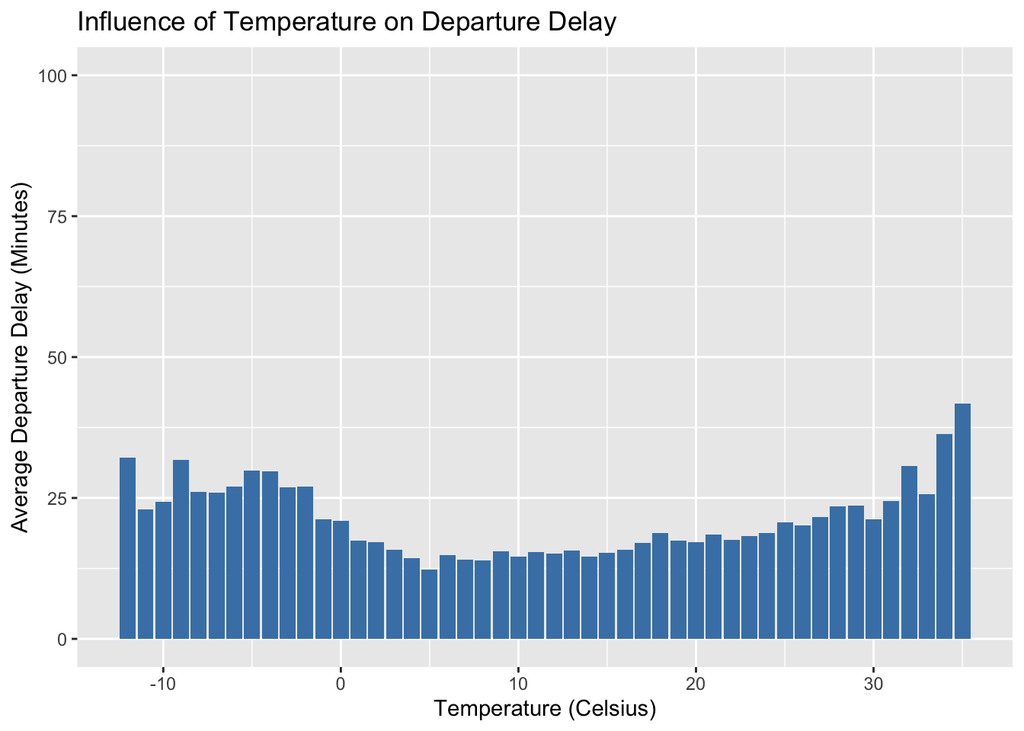

```r
average_delay_temperature <- delay_departure_data %>%
  group_by(temperature_celsius) %>%
  summarize(average_delay = mean(delay_departure_min, na.rm = TRUE), count = n())

ggplot(average_delay_temperature, aes(x = temperature_celsius, y = average_delay)) +
  geom_bar(stat = "identity", fill = "steelblue") +
  labs(x = "Temperature (Celsius)", y = "Average Departure Delay (Minutes)") +
  ggtitle("Influence of Temperature on Departure Delay") +
  coord_cartesian(ylim = c(0, 100))
```

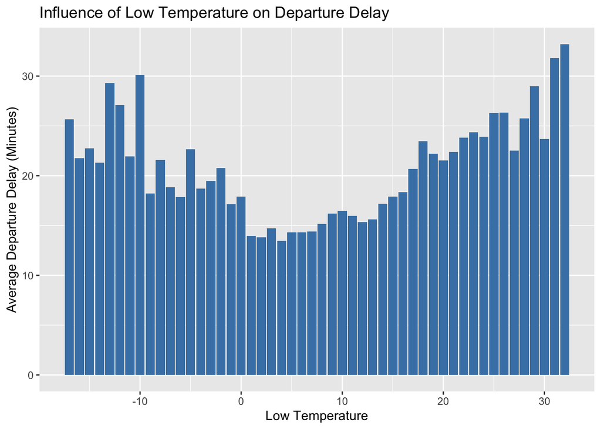

```r
average_delay_templow <- delay_departure_data %>%
  group_by(temperature_celsius_low) %>%
  summarize(average_delay = mean(delay_departure_min, na.rm = TRUE))

ggplot(average_delay_templow, aes(x = temperature_celsius_low, y = average_delay)) +
  geom_bar(stat = "identity", fill = "steelblue") +
  labs(x = "Low Temperature", y = "Average Departure Delay (Minutes)") +
  ggtitle("Influence of Low Temperature on Departure Delay")
```

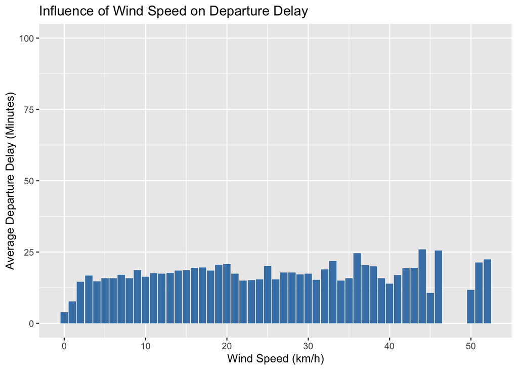

```r
average_delay_wind <- delay_departure_data %>%
  group_by(wind_speed_km) %>%
  summarize(average_delay = mean(delay_departure_min, na.rm = TRUE))

ggplot(average_delay_wind, aes(x = wind_speed_km, y = average_delay)) +
  geom_bar(stat = "identity", fill = "steelblue") +
  labs(x = "Wind Speed (km/h)", y = "Average Departure Delay (Minutes)") +
  ggtitle("Influence of Wind Speed on Departure Delay") +
  coord_cartesian(ylim = c(0, 100))
```

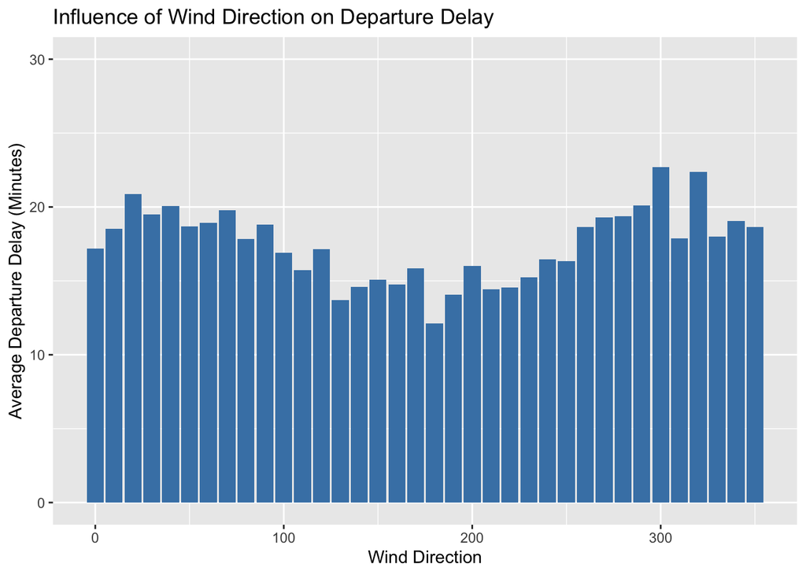

```r
average_delay_wind_direction <- delay_departure_data %>%
  group_by(wind_direction) %>%
  summarize(average_delay = mean(delay_departure_min, na.rm = TRUE))

ggplot(average_delay_wind_direction, aes(x = wind_direction, y = average_delay)) +
  geom_bar(stat = "identity", fill = "steelblue") +
  labs(x = "Wind Direction", y = "Average Departure Delay (Minutes)") +
  ggtitle("Influence of Wind Direction on Departure Delay") +
  coord_cartesian(ylim = c(0, 30))
```

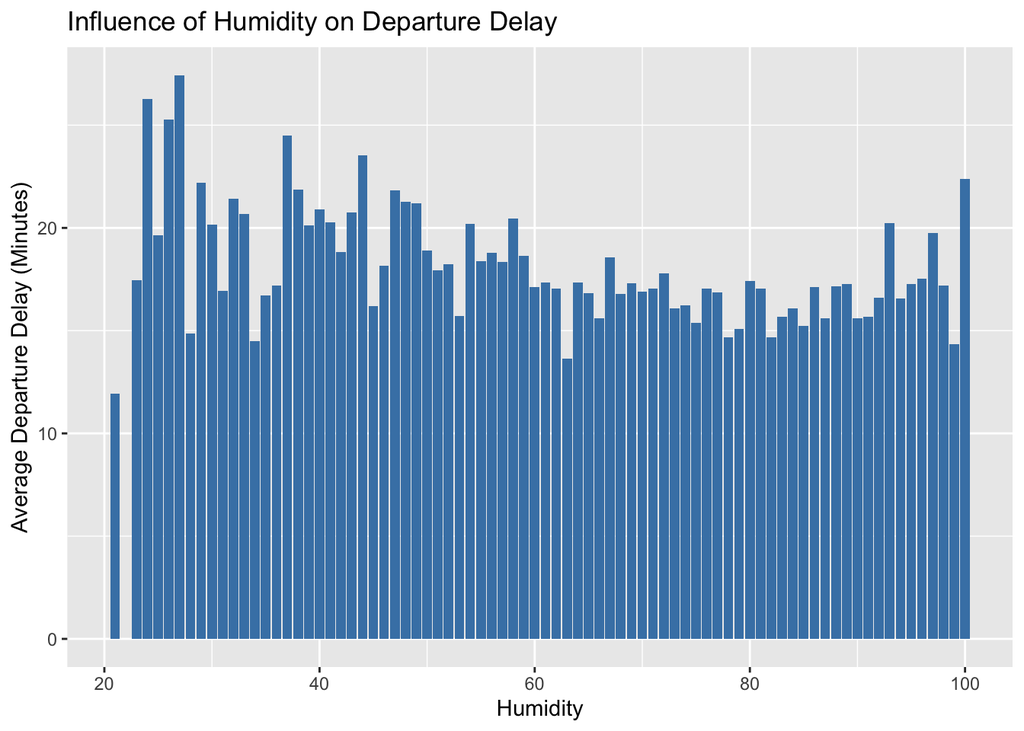

```r
average_delay_humidity <- delay_departure_data %>%
  group_by(humidity) %>%
  summarize(average_delay = mean(delay_departure_min, na.rm = TRUE))

ggplot(average_delay_humidity, aes(x = humidity, y = average_delay)) +
  geom_bar(stat = "identity", fill = "steelblue") +
  labs(x = "Humidity", y = "Average Departure Delay (Minutes)") +
  ggtitle("Influence of Humidity on Departure Delay")
```

Looking at barometric pressure, I can personally not see any interessting trends…

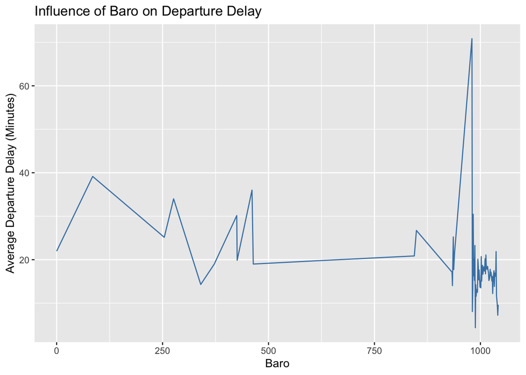

```r
average_delay_baro <- delay_departure_data %>%
  group_by(baro) %>%
  summarize(average_delay = mean(delay_departure_min, na.rm = TRUE))

ggplot(average_delay_baro, aes(x = baro, y = average_delay)) +
  geom_line(color = "steelblue") +
  labs(x = "Baro", y = "Average Departure Delay (Minutes)") +
  ggtitle("Influence of Baro on Departure Delay")
```

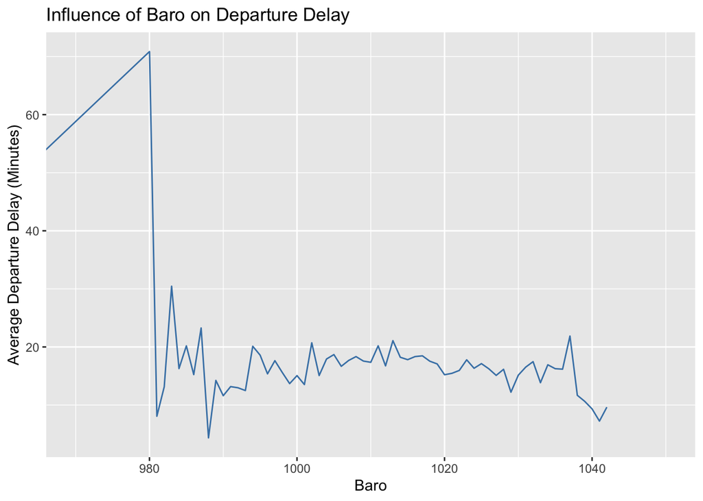

```r
ggplot(average_delay_baro, aes(x = baro, y = average_delay)) +
  geom_line(color = "steelblue") +
  labs(x = "Baro", y = "Average Departure Delay (Minutes)") +
  ggtitle("Influence of Baro on Departure Delay") +
  coord_cartesian(xlim = c(970, 1050))
```

```r
summary(average_delay_baro)
```

```
##       baro        average_delay
##  Min.   :   0.0   Min.   : 4.348
##  1st Qu.: 982.0   1st Qu.:15.085
##  Median :1002.0   Median :17.130
##  Mean   : 910.6   Mean   :18.353
##  3rd Qu.:1022.0   3rd Qu.:19.818
##  Max.   :1042.0   Max.   :70.857
##  NA's   :1
```